# Predictive Modeling of Annual Inflation Using Weighted Least Squares Regression

Annisa Indriani

2024-10-30

## Load Library

```r
library(readxl)
library(lmtest)
library(nortest)
library(car)
library(dplyr)
```

```r
library(ggplot2)
library(reshape2)
library(performance)
library(gamlr)
```

## Import Data

```r
gdp = read_excel("Dataset Kesejahteraan Sosial dan Ekonomi Negara Asia 2022.xlsx",
                 sheet = 2)
gdp
```

```
## # A tibble: 20 × 13
##    Region    Country  Income_Group Households_Consumpti…¹ Government_Consumpti…²
##    <chr>     <chr>    <chr>                         <dbl>                  <dbl>
##  1 Southeast Indones… Upper middle                   4.94                -4.51
##  2 Southeast Malaysia Upper middle                  11.3                  3.94
##  3 Southeast Singapo… High                           9.67                -2.33
##  4 Southeast Brunei … High                           9.89                 6.86
##  5 Southeast Philipp… Lower middle                   8.29                 4.89
##  6 Southeast Cambodia Lower middle                  16.7                -41.6
##  7 Southeast Thailand Upper middle                   6.34                -0.0413
##  8 East      Hong Ko… High                          -1.21                 8.15
##  9 East      Macao S… High                          -8.87                -0.0655
## 10 East      Korea, … High                           4.34                 4.13
## 11 East      Mongolia Lower middle                   7.38                 5.45
## 12 West      Armenia  Upper middle                   7.98                 6.5
## 13 West      Cyprus   High                           7.71                 0.120
## 14 West      Georgia  Upper middle                  -1.85                -4.64
## 15 West      Saudi A… High                           4.82                 6.70
## 16 Central   Uzbekis… Lower middle                  11.4                  1.33
## 17 South     Banglad… Lower middle                   7.48                 6.24
## 18 South     India    Lower middle                   7.34                 1.24
## 19 South     Pakistan Lower middle                   9.97                -3.40
## 20 South     Sri Lan… Lower middle                  -9.00                 1.39
## # ℹ abbreviated names: ¹Households_Consumption_Expenditure_Annual_Growth,
## #   ²Government_Consumption_Expenditure_Annual_Growth
## # ℹ 8 more variables: Age_Dependency_Ratio <dbl>,
## #   Unemployment_Total_Labor_Force <dbl>, Urban_Population <dbl>,
## #   Inflation_GDP <dbl>, GDP_per_Capita_Annual_Growth <dbl>,
## #   Imports_Goods_and_Services <dbl>, Consumer_Price_Index <dbl>,
## #   Inflation_Consumer_Prices_Annual <dbl>
```

## Exploratory Data Analysis

### Check Data Structure

```r
str(gdp)
```

```
## tibble [20 × 13] (S3: tbl_df/tbl/data.frame)
##  $ Region                                          : chr [1:20] "Southeast" "Southeast" "Southeast" "Southeast" ...
##  $ Country                                         : chr [1:20] "Indonesia" "Malaysia" "Singapore" "Brunei Darussalam" ...
##  $ Income_Group                                    : chr [1:20] "Upper middle" "Upper middle" "High" "High" ...
##  $ Households_Consumption_Expenditure_Annual_Growth: num [1:20] 4.94 11.31 9.67 9.89 8.29 ...
##  $ Government_Consumption_Expenditure_Annual_Growth: num [1:20] -4.51 3.94 -2.33 6.86 4.89 ...
##  $ Age_Dependency_Ratio                            : num [1:20] 47.2 43.2 36.9 39.3 55.7 ...
##  $ Unemployment_Total_Labor_Force                  : num [1:20] 3.55 3.73 2.76 7.2 2.24 ...
##  $ Urban_Population                                : num [1:20] 57.9 78.2 100 78.9 48 ...
##  $ Inflation_GDP                                   : num [1:20] 9.57 6.46 9.05 24.24 5.48 ...
##  $ GDP_per_Capita_Annual_Growth                    : num [1:20] 4.64 7.527 0.274 -2.423 6.008 ...
##  $ Imports_Goods_and_Services                      : num [1:20] 14.75 14.23 -1.89 9.54 13.94 ...
##  $ Consumer_Price_Index                            : num [1:20] 163 127 124 106 146 ...
##  $ Inflation_Consumer_Prices_Annual                : num [1:20] 4.21 3.38 6.12 3.68 5.82 ...
```

### **Check Summary**

```r
summary(gdp)
```

```
##     Region            Country          Income_Group
##  Length:20          Length:20          Length:20
##  Class :character   Class :character   Class :character
##  Mode  :character   Mode  :character   Mode  :character
##
##
##
##  Households_Consumption_Expenditure_Annual_Growth
##  Min.   :-9.002
##  1st Qu.: 4.696
##  Median : 7.427
##  Mean   : 5.731
##  3rd Qu.: 9.724
##  Max.   :16.729
##  Government_Consumption_Expenditure_Annual_Growth Age_Dependency_Ratio
##  Min.   :-41.58364                                Min.   :36.91
##  1st Qu.: -0.63067                                1st Qu.:42.65
##  Median :  1.36038                                Median :47.35
##  Mean   :  0.01813                                Mean   :48.43
##  3rd Qu.:  5.64440                                3rd Qu.:53.62
##  Max.   :  8.15112                                Max.   :69.03
##  Unemployment_Total_Labor_Force Urban_Population Inflation_GDP
##  Min.   : 0.361                 Min.   : 19.03   Min.   : 0.3675
##  1st Qu.: 2.780                 1st Qu.: 45.91   1st Qu.: 5.3731
##  Median : 5.346                 Median : 61.94   Median : 8.1905
##  Mean   : 5.353                 Mean   : 62.48   Mean   :10.6953
##  3rd Qu.: 7.033                 3rd Qu.: 79.50   3rd Qu.:13.2113
##  Max.   :12.557                 Max.   :100.00   Max.   :48.8473
##  GDP_per_Capita_Annual_Growth Imports_Goods_and_Services Consumer_Price_Index
##  Min.   :-27.663              Min.   :-19.875            Min.   :106.5
##  1st Qu.:  1.912              1st Qu.:  3.998            1st Qu.:126.6
##  Median :  4.119              Median : 14.084            Median :146.4
##  Mean   :  2.268              Mean   : 11.484            Mean   :175.3
##  3rd Qu.:  6.075              3rd Qu.: 18.831            3rd Qu.:207.9
##  Max.   : 13.025              Max.   : 33.800            Max.   :395.7
##  Inflation_Consumer_Prices_Annual
##  Min.   : 1.045
##  1st Qu.: 4.078
##  Median : 6.099
##  Mean   : 9.232
##  3rd Qu.: 9.342
##  Max.   :49.721
```

### **Check Missing Values**

```r
colSums(is.na(gdp))
```

```
##                                           Region
##                                                0
##                                          Country
##                                                0
##                                     Income_Group
##                                                0
## Households_Consumption_Expenditure_Annual_Growth
##                                                0
## Government_Consumption_Expenditure_Annual_Growth
##                                                0
##                             Age_Dependency_Ratio
##                                                0
##                   Unemployment_Total_Labor_Force
##                                                0
##                                 Urban_Population
##                                                0
##                                    Inflation_GDP
##                                                0
##                     GDP_per_Capita_Annual_Growth
##                                                0
##                       Imports_Goods_and_Services
##                                                0
##                             Consumer_Price_Index
##                                                0
##                 Inflation_Consumer_Prices_Annual
##                                                0
```

### **Correlation Heatmap**

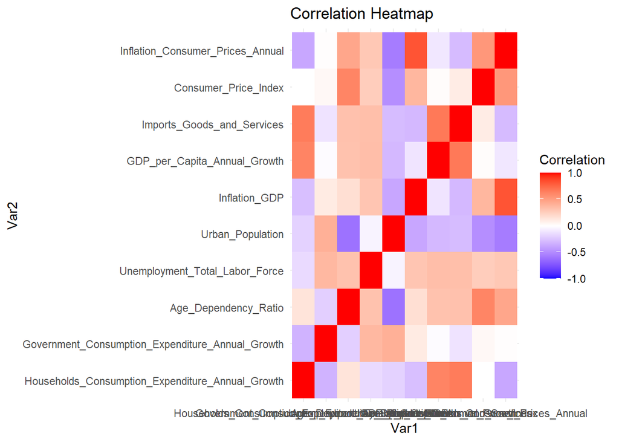

```r
correlation_matrix <- cor(gdp %>% select_if(is.numeric))

melted_correlation <- melt(correlation_matrix)
ggplot(data = melted_correlation, aes(x = Var1, y = Var2, fill = value)) +
  geom_tile() +
  scale_fill_gradient2(low = 'blue', high = 'red', mid = 'white',
                       midpoint = 0, limit = c(-1, 1), name = 'Correlation') +
  theme_minimal() +
  labs(title = 'Correlation Heatmap')
```

## **Linear Regression Model**

```r
model1 = lm(Inflation_Consumer_Prices_Annual ~
              Households_Consumption_Expenditure_Annual_Growth +
              Age_Dependency_Ratio +
              Inflation_GDP, data = gdp)
summary(model1)
```

```
##
## Call:
## lm(formula = Inflation_Consumer_Prices_Annual ~ Households_Consumption_Expenditure_Annual_Growth +
##     Age_Dependency_Ratio + Inflation_GDP, data = gdp)
##
## Residuals:
##     Min      1Q  Median      3Q     Max
## -8.7839 -2.4339  0.3778  3.3399  6.4547
##
## Coefficients:
##                                                  Estimate Std. Error t value
## (Intercept)                                      -19.7729     6.4813  -3.051
## Households_Consumption_Expenditure_Annual_Growth  -0.3918     0.1738  -2.255
## Age_Dependency_Ratio                               0.4928     0.1368   3.602
## Inflation_GDP                                      0.6903     0.1057   6.531
##                                                  Pr(>|t|)
## (Intercept)                                       0.00763 **
## Households_Consumption_Expenditure_Annual_Growth  0.03850 *
## Age_Dependency_Ratio                              0.00239 **
## Inflation_GDP                                    6.92e-06 ***
## ---
## Signif. codes:  0 '***' 0.001 '**' 0.01 '*' 0.05 '.' 0.1 ' ' 1
##
## Residual standard error: 4.623 on 16 degrees of freedom
## Multiple R-squared:  0.8394, Adjusted R-squared:  0.8093
## F-statistic: 27.88 on 3 and 16 DF,  p-value: 1.366e-06
```

From the summary above, we can see that the model is significant because the p-value is less than alpha 0.05. In addition, the variables also have p-values below 0.05, indicating a relationship between Households Consumption Expenditure Annual Growth, Age Dependency Ratio, Inflation GDP, and Inflation Consumer Prices Annual.

## **Assumptions Test**

### **Independent**

```r
dwtest(model1)
```

```
##
##  Durbin-Watson test
##
## data:  model1
## DW = 2.013, p-value = 0.425
## alternative hypothesis: true autocorrelation is greater than 0
```

The Durbin-Watson test shows that the model has a p-value of more than alpha 0.05, which indicates that the independence assumption is met.

### **Identic**

```r
bptest(model1)
```

```
##
##  studentized Breusch-Pagan test
##
## data:  model1
## BP = 12.982, df = 3, p-value = 0.004675
```

The Breusch Pagan test shows that the model has a p-value of less than 0.05, which indicates that the identical assumption is not met, and therefore, the model cannot be used for further analysis. Thus, a weighted least squares regression model will be used to deal with this issue.

### **Normality**

```r
e1 <- residuals(model1)
shapiro.test(e1)
```

```
##
##  Shapiro-Wilk normality test
##
## data:  e1
## W = 0.96394, p-value = 0.6251
```

The Shapiro-Wilk test shows that the model has a p-value of more than alpha 0.05, which indicates that the normality assumption is met.

### **Multicollinearity**

```r
vif(model1)
```

```
## Households_Consumption_Expenditure_Annual_Growth
##                                         1.127180
##                             Age_Dependency_Ratio
##                                         1.072690
##                                    Inflation_GDP
##                                         1.137314
```

A VIF value of less than 10 indicates that there is no multicollinearity between Households Consumption Expenditure, Annual Growth, and Age Dependency Ratio.

## **Weighted Least Squares Regression Model**

```r
weight1 = 1 / lm(abs(model1$residuals) ~ model1$fitted.values)$fitted.values^2

model_wls1 <- lm(Inflation_Consumer_Prices_Annual ~
                   Households_Consumption_Expenditure_Annual_Growth +
                   Age_Dependency_Ratio + Inflation_GDP, data = gdp,
                 weights = weight1)
summary(model_wls1)
```

```
##
## Call:
## lm(formula = Inflation_Consumer_Prices_Annual ~ Households_Consumption_Expenditure_Annual_Growth +
##     Age_Dependency_Ratio + Inflation_GDP, data = gdp, weights = weight1)
##
## Weighted Residuals:
##      Min       1Q   Median       3Q      Max
## -2.35933 -0.61633  0.03474  0.86401  2.28488
##
## Coefficients:
##                                                  Estimate Std. Error t value
## (Intercept)                                      -17.7517     6.3379  -2.801
## Households_Consumption_Expenditure_Annual_Growth  -0.3044     0.1681  -1.810
## Age_Dependency_Ratio                               0.4571     0.1362   3.355
## Inflation_GDP                                      0.6111     0.1196   5.109
##                                                  Pr(>|t|)
## (Intercept)                                      0.012818 *
## Households_Consumption_Expenditure_Annual_Growth 0.089058 .
## Age_Dependency_Ratio                             0.004024 **
## Inflation_GDP                                    0.000105 ***
## ---
## Signif. codes:  0 '***' 0.001 '**' 0.01 '*' 0.05 '.' 0.1 ' ' 1
##
## Residual standard error: 1.315 on 16 degrees of freedom
## Multiple R-squared:  0.7485, Adjusted R-squared:  0.7013
## F-statistic: 15.87 on 3 and 16 DF,  p-value: 4.715e-05
```

```r
model2 = lm(Inflation_Consumer_Prices_Annual ~
              Age_Dependency_Ratio +
              Inflation_GDP, data = gdp)

weight2 = 1 / lm(abs(model2$residuals) ~ model2$fitted.values)$fitted.values^2

model_wls2 <- lm(Inflation_Consumer_Prices_Annual ~
                   Age_Dependency_Ratio + Inflation_GDP, data = gdp,
                 weights = weight2)
summary(model_wls2)
```

```
##
## Call:
## lm(formula = Inflation_Consumer_Prices_Annual ~ Age_Dependency_Ratio +
##     Inflation_GDP, data = gdp, weights = weight2)
##
## Weighted Residuals:
##     Min      1Q  Median      3Q     Max
## -1.9929 -0.8350  0.0885  0.6471  2.8289
##
## Coefficients:
##                      Estimate Std. Error t value Pr(>|t|)
## (Intercept)          -12.2857     5.7467  -2.138  0.04735 *
## Age_Dependency_Ratio   0.3304     0.1278   2.585  0.01925 *
## Inflation_GDP          0.4805     0.1333   3.606  0.00218 **
## ---
## Signif. codes:  0 '***' 0.001 '**' 0.01 '*' 0.05 '.' 0.1 ' ' 1
##
## Residual standard error: 1.205 on 17 degrees of freedom
## Multiple R-squared:  0.6096, Adjusted R-squared:  0.5637
## F-statistic: 13.27 on 2 and 17 DF,  p-value: 0.0003373
```

From the summary above, we can see that the model is significant because the p-value is less than alpha 0.05. In addition, the variables also has a p-value below 0.05, which means there is a relationship between Age Dependency Ratio, Inflation GDP, and Inflation Consumer Prices Annual.

### Breusch-Pagan Test

```r
bptest(model_wls2)
```

```
##
##  studentized Breusch-Pagan test
##
## data:  model_wls2
## BP = 0.23062, df = 2, p-value = 0.8911
```

## **Goodness of the Model**

### **AIC**

```r
AIC(model1)
```

```
## [1] 123.5396
```

```r
AIC(model_wls1)
```

```
## [1] 122.0385
```

```r
AIC(model_wls2)
```

```
## [1] 117.4246
```

### RSE

```r
summary(model1)$sigma
```

```
## [1] 4.623361
```

```r
summary(model_wls1)$sigma
```

```
## [1] 1.315236
```

```r
summary(model_wls2)$sigma
```

```
## [1] 1.204728
```

Based on the AIC and RSE values, it can be seen that the WLS model with significant variables has a smaller value than other models. Thus, the model is the best model and can be used for analysis.